# Basic Operations in the MATLAB/Octave Programming Language

# Common MATLAB/Octave Functions

## help

The "help" function can be used to find information about any MATLAB/Octave function. See the example below.

```matlab
help magic
```

```
'magic' is a function from the file /usr/share/octave/4.2.2/m/special-matrix/magic.m

 -- magic (N)

     Create an N-by-N magic square.

     A magic square is an arrangement of the integers '1:n^2' such that
     the row sums, column sums, and diagonal sums are all equal to the
     same value.

     Note: N must be a scalar greater than or equal to 3.  If you supply
     N less than 3, magic returns either a nonmagic square, or else the
     degenerate magic squares 1 and [].

Additional help for built-in functions and operators is
available in the online version of the manual.  Use the command
'doc <topic>' to search the manual index.

Help and information about Octave is also available on the WWW
at http://www.octave.org and via the help@octave.org
mailing list.
```

## ones() and zeros()

Often, it is useful to create arrays of a particular size that are filled with a particular number. The ones() and zeros() functions are easy ways to do this. zeros() produces a matrix filled with all zeros, and ones() produces a matrix filled with all ones (this can be used to fill a matrix with any constant number).

See the example below. Both take two arguments. The first one is the number of rows you want, and the second is the number of columns.

```matlab
%create a 1x10 matrix of all zeros.
a = zeros(1,10)
%create a 2x5 matrix of all ones
b = ones(2,5)
%create a 1x5 matrix of all 3.5
c = 3.5*ones(1,5)
```

```
a =

   0   0   0   0   0   0   0   0   0   0

b =

   1   1   1   1   1
   1   1   1   1   1

c =

    3.5000    3.5000    3.5000    3.5000    3.5000
```

## Size

The size() function returns the number of rows and the number of columns in a matrix, in that order. See the example below.

```matlab
array1 = 0:0.2:10; % here are 3 different arrays each with their own size of values
array2 = 0:0.4:10;
array3 = [ 1 2 3 4 5 6 7 8 9 10 11 12 13 14 15 16 17 18 19 20];

% to easily find the size of these arrays you can use size(name of array)
% the answer you obtain tells you what your array is like and it comes in
% the format of rows then columns`

size(array1)
display('1 row, 51 columns')

size(array2)
display('1 row, 26 columns')

size(array3)
display('1 row, 20 columns')

% this function is helpful when trying to assess vector length errors
```

```
ans =

    1   51

1 row, 51 columns
ans =

    1   26

1 row, 26 columns
ans =

    1   20

1 row, 20 columns
```

## Length

The length() function returns the largest dimension (rows or columns) in a vector. See the example below.

```matlab
a = [1 2; 3 4; 5 6]
length(a)
```

```
a =

   1   2
   3   4
   5   6

ans =  3
```

In this case, since "a" had 3 rows and 2 columns, it returns "3" as the length.

## plot()

**by: Liam T**

The plot() function allows us to create figures of our data that we find in an xy plane.

You want to use the format:

```
figure
plot(x-axis array,y-axis array,'type of line')
xlabel('name of x axis data (w/units)')
ylabel('name of y axis data (w/units)')
legend('name of the line')
```

There are many line styles you can use (see "help plot" for more).

They all follow the format: color,point type, line type.

Some examples are given below:

'bo-' gives you a blue(b) line(-) with circle points(o)

'k.-' gives you a black(k) line(-) with . points(.)

See the code cell below for some examples

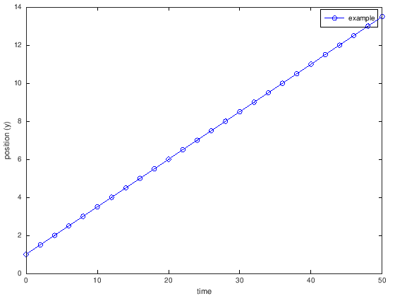

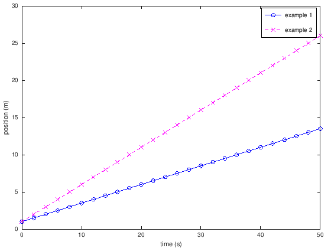

```matlab
t = 0:2:50; % array for time, starting at 0, counting by 2s up to 50
m = 1/4; % slope of the line
b = 1; % y-intercept
y = (m * t) + b; % equation created for graphing example

figure
plot(t,y,'bo-') % things that are plotted against one another must be the same size
xlabel('time') % name of the first component in plot
ylabel('position (y)') % name of the second component in plot
legend('example') % name of the line that is being graphed

% its also possible to graph more than one line on a certain graph

m2 = 1/2; % new slope
y2 = (m2 * t) + b; % new equation with new slope

% you can create a whole new graph by creating another 'figure'

figure
plot(t,y,'bo-',t,y2,'mx--') % if you wanted to add a third line you would follow this pattern
xlabel('time (s)')
ylabel('position (m)')
legend('example 1','example 2') % because there are 2 lines being graphed you now need 2 names
```

## xlim() and ylim() to set plot limits

You can set the limits of a plot using xlim() and ylim() functions. An example is below.

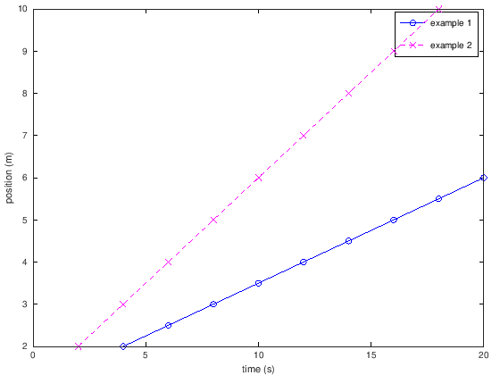

```matlab
figure
plot(t,y,'bo-',t,y2,'mx--') % if you wanted to add a third line you would follow this pattern
xlabel('time (s)')
ylabel('position (m)')
legend('example 1','example 2') % because there are 2 lines being graphed you now need 2 names

%now cut off the time so I only look at the first 20 seconds
xlim([0 20])
%now crop in the y so I only look at y values from 2 to 10
ylim([2 10])
```

## find()

The `find()` function allows to to locate an element in an array that satisfies a condition. Use "help find" to see all of the possible inputs to this function and how to use them. As a quick example, suppose you have the function:

$$y = 1-e^{-t}$$

and you'd like to know at what time this function is first greater than or equal to 0.632. This could be accomplished using the following code:

```
my_index =  101
my_y =  0.63212
my_time =  1
```

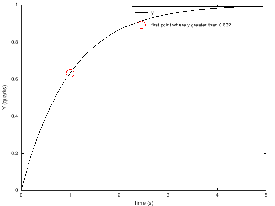

```matlab
clear all
%set up variable to hold time values
t = 0:.01:5;
%implement my equation:
y = 1 - exp(-t);
%use find to locate which VALUE in my array y is greater than .632.
my_index = find(y>0.632,1,'first') %tells the find() command to find one index in the array y
%(the first one) for which y is greater than 0.632.
%this index will be an integer between 1 and the length of y, allowing me to use it to "index" the variable
%and find the values I'm interested in

%now, to use this, I would like to see which y value that is, and at what time it occurs:
my_y = y(my_index)
my_time = t(my_index)

%just to make this visual, let's plot y vs. t, and also plot our "found" value on top.
figure
plot(t,y,'k',my_time,my_y,'ro','MarkerSize',15)
xlabel('Time (s)')
ylabel('Y (quarks)')
legend('y','first point where y greater than 0.632')
```

## polyfit()

MATLAB/Octave can be used to estimate a "best fit" polynomial function to match a dataset. The term "best fit," in this context, means that the sum of the squared error between the model and the data is minimized. The command used to produce the set of coefficients is "polyfit." An example of how to use the "polyfit" command to produce the best-fit line for a dataset is shown below.

```
m_estimate = -3.0284
b_estimate =  4.0670
```

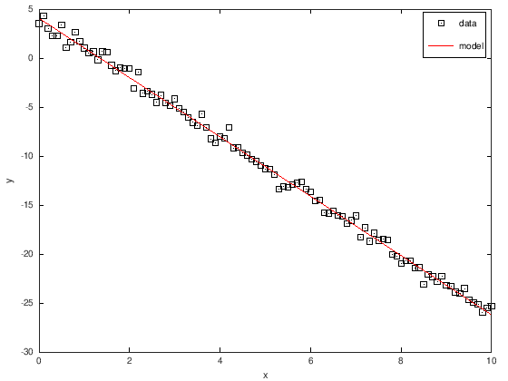

```matlab
% first, create some fake "data" we will fit a line to, in order to see how "polyfit" works.
xfakedata = 0:.1:10;
yfakedata = -3*xfakedata + 4 + .5*randn(size(xfakedata)); %the randn() on the end produces some random "noise" on our fake data.
%this simulates the effect of having error in our measurements. If polyfit does its job, we should get the line y = -3x+4 back!

%now we will actually use polyfit. The array "coefficients" will contain [m b] in the equation y = m*x+b.
%the second argument to the polyfit() function is the ORDER of the polynomial. A line is a polynomial of order 1.
%for reference, a quadratic is a polynomial of order 2.
coefficients = polyfit(xfakedata,yfakedata,1);
%was m=-3 and b=4?
m_estimate = coefficients(1)
b_estimate = coefficients(2)

%now, these coefficients fully define a "model" of our relationship y = m*x+b. Let's produce predictions based on this model
ymodel = m_estimate*xfakedata + b_estimate;

%now plot the data and the model together to evaluate.
figure
plot(xfakedata,yfakedata,'ks',xfakedata,ymodel,'r')
xlabel('x')
ylabel('y')
legend('data','model')
```

# Common Errors

Errors are common, even if you're an expert programmer. Reading the error carefully will give you an idea of what is wrong with your code. Below are some common error archetypes and some hints about what they mean. As you debug your code, talking your way through every term in every line can help!

## error: index (something): out of bound 1

This usually means you're trying to index a variable that is either not a matrix, or is a matrix that is too small for the index you're requesting. See the example below:

```matlab
% set a as one number
a = 1;
%try to access the 3rd element in a
a(3)
%let's say b is actually a matrix
b = ones(2,2)
%but we try to access the 3rd row, 1st column. The error looks slightly different, but the effect is the same.
b(3,1)
```

```
error: a(3): out of bound 1
b =

   1   1
   1   1

error: b(3,_): but b has size 2x2
```

## error: plt2vv: vector lengths must match

This usually occurs if we try to plot a pair of x and y data that are not the same size. See the example below.

```
error: __plt2vv__: vector lengths must match
error: called from
    __plt__>__plt2vv__ at line 489 column 5
    __plt__>__plt2__ at line 248 column 14
    __plt__ at line 113 column 17
    plot at line 223 column 10
```

[figure not shown]

```matlab
t = 1:2:10; %time vector goes 1 3 5 7 9, having length 5
y = 1:10; %y vector goes  1 2 3 4 5 6 7 8 9 10, having length 10

plot(t,y)
```

## error: =: nonconformant arguments (op1 is 1x1, op2 is somethingx1)

This error often indicates that you are trying to set one element in a matrix equal to another variable that has many elements. See the example below:

```matlab
%say we have a vector v
v = 0:.1:2;

%now we have some other vector q
q = zeros(1,10)

%now let's imagine we tried to set the third element in q to v
q(3) = v

%we get the error! What we COULD do is set the third element in q to v(3) .
q(3) = v(3)
```

```
q =

   0   0   0   0   0   0   0   0   0   0

error: =: nonconformant arguments (op1 is 1x1, op2 is 1x21)
q =

 Columns 1 through 8:

   0.00000   0.00000   0.20000   0.00000   0.00000   0.00000   0.00000   0.00000

 Columns 9 and 10:

   0.00000   0.00000
```

## error: 'something' undefined near line 1 column something

This error means that I am attempting to use a variable in a calculation before it is defined. See the example below:

```matlab
clear all
%say I try to perform a calculation that uses a variable "b." I have defined no such variable yet.
a = 2*b
%NOW I define b
b = 2
```

```
error: 'b' undefined near line 2 column 7
b =  2
```

## error: subscripts must be either integers 1 to (2^31)-1 or logicals

In the "indexing" introduction, we mentioned that we can access parts of a matrix by specifying row and column. This error means that we're attempting to access a "partial row" or "partial column" of a matrix. See the example below:

```matlab
a = [1 2 3]
%this works:
a(2)
%but this does not.
a(.2)
%and neither does this, since there is no 0 index in matlab
a(0)
```

```
a =

   1   2   3

ans =  2
error: a(0.2): subscripts must be either integers 1 to (2^31)-1 or logicals
error: a(0): subscripts must be either integers 1 to (2^31)-1 or logicals
```

This error is also common if you forget to include a `*` between two parenthetical quantities you were trying to multiply. See the example below:

```matlab
a = 1;
b = 2;
c = 3;

%this won't work!
d = c/((1+a)(2.3+b))

%but this will!
d = c/((1+a)*(2.3+b))
```

```
error: index (4.3): subscripts must be either integers 1 to (2^31)-1 or logicals
d =  0.34884
```

## parse error or syntax error:

Parse errors are hard to track down, but they usually mean that you have typed something that Octave doesn't know how to interpret. An example is given below:

```matlab
a = 2
1$
```

```
a =  2
parse error:

  syntax error

>>> 1$
     ^
```

Syntax errors are also common if you are missing a parenthesis, or if you have an extra one! See the example below.

```matlab
a = 2;
b = 3;
g = 10;

(a+2))
```

```
parse error:

  syntax error

>>> (a+2))
         ^
```